# R Notebook

```r
library(glmnet)
```

# Data Prep

## BEA

### API

| TableName | SeriesCode | LineNumber | LineDescription | METRIC_NAME | CL_UNIT | UNIT_MULT | DataValue_2014M01 | DataValue_2014M02 | DataValue_2014M03 | DataValue_2014M04 | DataValue_2014M05 | DataValue_2014M06 | DataValue_2014M07 | DataValue_2014M08 | DataValue_2014M09 | DataValue_2014M10 | DataValue_2014M11 | DataValue_2014M12 | DataValue_2015M01 | DataValue_2015M02 | DataValue_2015M03 | DataValue_2015M04 | DataValue_2015M05 | DataValue_2015M06 | DataValue_2015M07 | DataValue_2015M08 | DataValue_2015M09 | DataValue_2015M10 | DataValue_2015M11 | … |
| --- | --- | --- | --- | --- | --- | --- | --- | --- | --- | --- | --- | --- | --- | --- | --- | --- | --- | --- | --- | --- | --- | --- | --- | --- | --- | --- | --- | --- | --- | --- |
| U20403 | DTAERA | 64 | Therapeutic appliances and equipment (42) | Fisher Quantity Index | Level | 0 | 102.975 | 103.732 | 103.908 | 104.760 | 105.923 | 106.157 | 106.360 | 107.174 | 107.414 | 108.592 | 108.297 | 106.734 | 110.796 | 110.513 | 109.862 | 109.835 | 109.013 | 110.489 | 112.484 | 113.267 | 109.289 | 112.189 | 112.991 | … |
| U20403 | DTMERA | 65 | Therapeutic medical equipment | Fisher Quantity Index | Level | 0 | 104.980 | 106.482 | 106.748 | 107.391 | 108.974 | 109.684 | 109.390 | 110.603 | 111.129 | 111.888 | 112.238 | 111.478 | 115.636 | 115.462 | 115.964 | 115.695 | 115.246 | 117.418 | 119.601 | 120.514 | 118.450 | 120.819 | 121.774 | … |
| U20403 | DEYERA | 66 | Corrective eyeglasses and contact lenses | Fisher Quantity Index | Level | 0 | 101.498 | 101.713 | 101.824 | 102.826 | 103.687 | 103.579 | 104.140 | 104.665 | 104.697 | 106.177 | 105.416 | 103.275 | 107.266 | 106.906 | 105.429 | 105.575 | 104.484 | 105.460 | 107.319 | 108.008 | 102.662 | 105.941 | 106.634 | … |
| U20403 | DPHMRA | 119 | Pharmaceutical and other medical products (40 and 41) | Fisher Quantity Index | Level | 0 | 108.324 | 108.559 | 110.241 | 110.328 | 111.683 | 111.591 | 112.107 | 113.237 | 113.507 | 113.599 | 113.786 | 114.768 | 114.883 | 113.988 | 115.171 | 115.277 | 116.126 | 116.944 | 118.043 | 118.921 | 118.917 | 119.797 | 119.996 | … |
| U20403 | DPNPRA | 120 | Pharmaceutical products | Fisher Quantity Index | Level | 0 | 108.369 | 108.587 | 110.287 | 110.366 | 111.718 | 111.615 | 112.141 | 113.269 | 113.536 | 113.620 | 113.805 | 114.808 | 114.875 | 113.970 | 115.162 | 115.273 | 116.137 | 116.940 | 118.026 | 118.904 | 118.924 | 119.787 | 119.977 | … |
| U20403 | DRXDRA | 121 | Prescription drugs | Fisher Quantity Index | Level | 0 | 109.062 | 109.093 | 111.074 | 111.164 | 112.615 | 112.431 | 113.051 | 114.078 | 114.660 | 114.229 | 114.381 | 115.653 | 115.376 | 114.466 | 115.547 | 115.786 | 116.797 | 117.369 | 118.587 | 119.566 | 119.411 | 120.515 | 120.589 | … |

### Clean

Each row looks like it corresponds to a distinct `SeriesCode`, so let’s confirm

```r
table(dat.bea$SeriesCode)
```

[output not shown]

There are 2 entries for “DHLCRA”

```r
dat.bea %>%
  filter(SeriesCode == "DHLCRA") %>%
  select(1:5)
```

We will create a unique key using both `SeriesCode` and `LineNumber`

```r
dat.bea %<>%
  mutate(SeriesLine = paste0(SeriesCode, "-", LineNumber)) %>%
  select(-c(SeriesCode, LineNumber)) %>%
  relocate(SeriesLine, .after = TableName)
```

Only pulling years 2014 through 2020 since the dependent variable (Hospital Volume, YoY%) is only observed in this time range.

### Format

| year | month | DDENRA-171 | DEYERA-66 | DFPHRA-181 | DFPNRA-185 | DGVHRA-182 | DHHCRA-173 | DHINRA-271 | DHLCRA-168 | DHLCRA-383 | DHPNRA-178 | DHSPRA-179 | DMINRA-272 | DMLBRA-174 | DNPHRA-180 | DNPNRA-184 | DNRDRA-122 | DNRSRA-183 | DOMDRA-175 | DOMORA-177 | DOMPRA-123 | DOMSRA-176 | DOUTRA-169 | DPHMRA-119 | DPHYRA-170 | DPMSRA-172 | DPNPRA-120 | DRXDRA-121 | DTAERA-64 | … |
| --- | --- | --- | --- | --- | --- | --- | --- | --- | --- | --- | --- | --- | --- | --- | --- | --- | --- | --- | --- | --- | --- | --- | --- | --- | --- | --- | --- | --- | --- | --- |
| 2014 | 1 | 97.259 | 101.498 | 96.342 | 102.329 | 104.789 | 106.196 | 113.838 | 101.102 | 101.102 | 100.914 | 100.882 | 114.743 | 98.288 | 100.602 | 98.666 | 104.740 | 101.086 | 101.816 | 101.717 | 104.781 | 101.855 | 101.332 | 108.324 | 101.454 | 102.724 | 108.369 | 109.062 | 102.975 | … |
| 2014 | 2 | 97.126 | 101.713 | 96.580 | 101.837 | 105.236 | 106.978 | 115.236 | 100.945 | 100.945 | 100.522 | 100.506 | 116.284 | 96.905 | 99.875 | 98.241 | 105.956 | 100.616 | 101.760 | 101.907 | 106.340 | 101.702 | 101.459 | 108.559 | 101.704 | 102.762 | 108.587 | 109.093 | 103.732 | … |
| 2014 | 3 | 97.229 | 101.824 | 97.548 | 101.447 | 105.710 | 107.406 | 116.492 | 101.298 | 101.298 | 100.814 | 100.879 | 117.638 | 97.226 | 100.109 | 98.595 | 106.143 | 100.479 | 102.509 | 102.978 | 106.658 | 102.323 | 101.888 | 110.241 | 102.105 | 103.363 | 110.287 | 111.074 | 103.908 | … |
| 2014 | 4 | 97.574 | 102.826 | 99.343 | 101.139 | 106.219 | 108.318 | 117.689 | 102.252 | 102.252 | 101.853 | 102.083 | 118.906 | 99.260 | 101.402 | 99.711 | 106.162 | 100.655 | 104.205 | 104.938 | 107.348 | 103.915 | 102.738 | 110.328 | 102.665 | 104.863 | 110.366 | 111.164 | 104.760 | … |
| 2014 | 5 | 97.944 | 103.687 | 100.696 | 101.450 | 106.683 | 108.751 | 118.721 | 103.033 | 103.033 | 102.722 | 103.035 | 119.957 | 100.650 | 102.421 | 100.376 | 106.978 | 101.085 | 105.304 | 106.364 | 108.971 | 104.884 | 103.410 | 111.683 | 103.246 | 105.795 | 111.718 | 112.615 | 105.923 | … |
| 2014 | 6 | 98.336 | 103.579 | 101.733 | 102.110 | 107.097 | 108.760 | 119.611 | 103.670 | 103.670 | 103.467 | 103.841 | 120.821 | 101.391 | 103.297 | 100.328 | 107.313 | 101.505 | 105.859 | 107.250 | 109.714 | 105.307 | 103.918 | 111.591 | 103.845 | 106.206 | 111.615 | 112.431 | 106.157 | … |

Now we do the same for BLS data before binding the two `mts` (multivariate time series) objects together

### API Note

While a maintained R interface to the API is nice to have for R users, it is often not available. We can get the same result from this API writing the request string directly, as follows:

```r
dat.bea <- paste0("https://apps.bea.gov/api/data?&",
                  "UserID=", bea_key, "&",
                  "method=GetData&",
                  "datasetname=NIUnderlyingDetail&",
                  "TableName=U20403&",
                  "Frequency=M&",
                  "Year=2014,2015,2016,2017,2018,2019,2020&",
                  "ResultFormat=JSON") %>%
  fromJSON(.)
```

## BLS

|  | year | period | periodName | value | seriesID |
| --- | --- | --- | --- | --- | --- |
| 1 | 2020 | M12 | December | 15979.3 | CES6562000101 |
| 2 | 2020 | M11 | November | 15935.4 | CES6562000101 |
| 3 | 2020 | M10 | October | 15905.9 | CES6562000101 |
| 4 | 2020 | M09 | September | 15835.9 | CES6562000101 |
| 5 | 2020 | M08 | August | 15758.3 | CES6562000101 |
| 6 | 2020 | M07 | July | 15686.2 | CES6562000101 |

Let’s confirm we got results for all of the original codes

```r
unique(dat.bls$seriesID) %>% length == length(bls_codes)
```

```
[1] TRUE
```

It seems like too many records - confirm uniqueness. There should be at most 7*12 = 84 records per `seriesID`

```r
## the first 10 codes
table(dat.bls$seriesID)[1:10]
```

```
CES6562000101 CES6562000107 CES6562000108 CES6562000134 CES6562000156 CES6562000181 CES6562111101 CES6562111156 CES6562111201 CES6562111256
         1344          1344          1344           672           672           336          1344           672          1344           672
```

Looking closer at one example…

```r
dat.bls %>% filter(seriesID == "CES6562000134",
                   year == 2014,
                   period == "M01")
```

[output not shown]

There appear to be a varying number of replicates for each seriesID. Not sure the reason - maybe something to do with more specific class codes grouped within a seriesID in the BLS database and the API is returning one record for each. Since the reported values are the same, I’ll just resolve the issue by filtering down to the first record for each.

```r
table(dat.bls$seriesID)[1:10]
```

```
CES6562000101 CES6562000107 CES6562000108 CES6562000134 CES6562000156 CES6562000181 CES6562111101 CES6562111156 CES6562111201 CES6562111256
           84            84            84            84            84            84            84            84            84            84
```

Restructure the data

| year | month | CES6562000101 | CES6562000107 | CES6562000108 | CES6562000134 | CES6562000156 | CES6562000181 | CES6562111101 | CES6562111156 | CES6562111201 | CES6562111256 | CES6562120001 | CES6562120007 | CES6562120008 | CES6562120034 | CES6562120056 | CES6562120081 | CES6562131001 | CES6562131007 | CES6562131008 | CES6562131034 | CES6562131056 | CES6562131081 | CES6562132001 | CES6562132007 | CES6562132008 | CES6562132034 | CES6562132056 | CES6562132081 | … |
| --- | --- | --- | --- | --- | --- | --- | --- | --- | --- | --- | --- | --- | --- | --- | --- | --- | --- | --- | --- | --- | --- | --- | --- | --- | --- | --- | --- | --- | --- | --- |
| 2014 | 1 | 14555.5 | 32.9 | 23.46 | 126.0 | 486154 | 422196 | 2339.3 | 80940 | 49.0 | 1499 | 877.8 | 26.6 | 22.95 | 118.4 | 24140 | 20197 | 127.4 | 25.7 | 17.75 | 128.2 | 3504 | 2480 | 122.2 | 30.4 | 17.71 | 141.9 | 3874 | 3049 | … |
| 2014 | 2 | 14571.8 | 32.9 | 23.47 | 126.1 | 486698 | 422749 | 2346.8 | 81199 | 49.4 | 1517 | 878.9 | 26.4 | 23.00 | 117.7 | 24082 | 20069 | 127.6 | 26.1 | 17.77 | 130.2 | 3522 | 2519 | 122.6 | 30.4 | 17.82 | 142.9 | 3862 | 3070 | … |
| 2014 | 3 | 14594.6 | 32.9 | 23.48 | 126.3 | 488919 | 423354 | 2351.7 | 81839 | 49.9 | 1537 | 883.9 | 27.1 | 22.92 | 121.4 | 24572 | 20699 | 126.8 | 26.4 | 17.80 | 131.2 | 3614 | 2537 | 123.0 | 31.1 | 17.88 | 145.9 | 3924 | 3135 | … |
| 2014 | 4 | 14606.4 | 33.0 | 23.49 | 126.8 | 489314 | 425017 | 2352.1 | 81853 | 50.9 | 1568 | 881.9 | 27.3 | 23.12 | 121.9 | 24693 | 20781 | 125.0 | 26.4 | 18.01 | 131.2 | 3525 | 2537 | 123.7 | 30.6 | 17.96 | 144.5 | 3934 | 3106 | … |
| 2014 | 5 | 14637.5 | 32.9 | 23.53 | 126.7 | 491820 | 424683 | 2355.2 | 81961 | 49.8 | 1529 | 882.9 | 27.0 | 23.21 | 120.6 | 24456 | 20566 | 125.8 | 26.3 | 17.88 | 131.9 | 3522 | 2551 | 123.3 | 30.5 | 18.12 | 143.0 | 3921 | 3074 | … |
| 2014 | 6 | 14650.5 | 32.9 | 23.56 | 126.8 | 490792 | 424913 | 2356.1 | 81992 | 50.6 | 1553 | 884.8 | 26.6 | 23.32 | 119.0 | 24244 | 20290 | 126.4 | 26.3 | 17.81 | 132.6 | 3539 | 2564 | 122.9 | 30.9 | 17.69 | 144.5 | 3871 | 3105 | … |

### Response

```r
y.ts <- zoo(y, start = c(2014, 1), frequency = 4)
```

```
Error in zoo(y, start = c(2014, 1), frequency = 4) :
  unused argument (start = c(2014, 1))
```

# EDA

## Time series (endogenous)

Viz the time series for Hospital Volume YoY% (y)

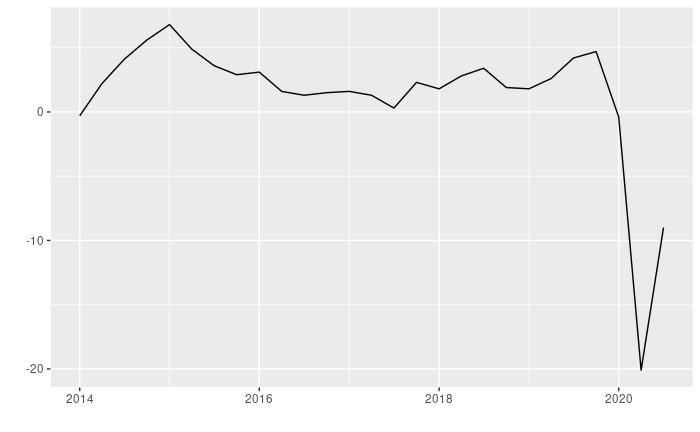

This shows no seasonality and appears to be a stationary process.

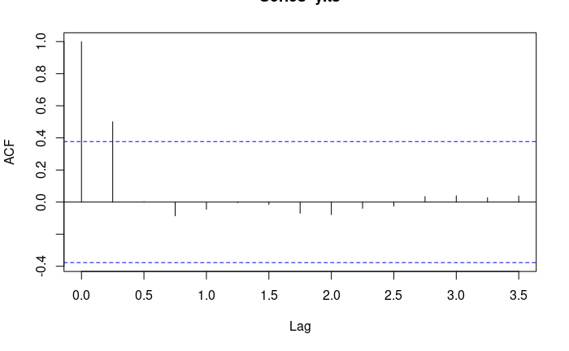

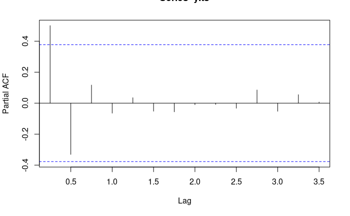

```r
summary(m1)
```

```
Call:
arima(x = y.ts, order = c(0, 0, 1))

Coefficients:
         ma1  intercept
      0.7284     1.4107
s.e.  0.2254     1.3314

sigma^2 estimated as 16.37:  log likelihood = -76.43,  aic = 158.85

Training set error measures:
                    ME     RMSE      MAE      MPE     MAPE     MASE       ACF1
Training set 0.0233512 4.045803 1.997741 57.76203 91.19075 0.878871 0.01822874
```

The quarterly time series regression without exogenous predictors

```r
forecast(m1, 10) %>% autoplot()
```

[output not shown]

Not much info here

## Disaggregate y

To work with different resolution predictors this is a common approach

```r
tail(y.ts_month)
```

```
            Apr        May        Jun        Jul        Aug        Sep
2020 -17.376946 -22.099349 -20.823704 -13.441642  -8.372554  -5.185804
```

### Join as `ts`

Bind all the features together

```r
dim(dat.ts)
```

```
[1]  81 251
```

Identify features with many NA

```r
na_cnt[!(names(na_cnt) %in% keep_list)]
```

```
  PCU33911333911321 PCU6211116211114111 PCU6211116211114112 PCU6211116211114113 PCU6211116211114114 PCU6211116211114121 PCU6211116211114122 PCU6211116211114123 PCU6211116211114124
                 35                  35                  35                  35                  35                  35                  35                  35                  50
PCU6211116211114131 PCU6211116211114132 PCU6211116211114133 PCU6211116211114134 PCU6211116211114142 PCU6211116211114143 PCU6211116211114144 PCU6211116211114151 PCU6211116211114152
                 35                  35                  35                  35                  35                  35                  35                  41                  35
PCU6211116211114153 PCU6211116211114154 PCU6211116211114191 PCU6211116211114192 PCU6211116211114193 PCU6211116211114194 PCU6211116211115111 PCU6211116211115112 PCU6211116211115113
                 35                  35                  35                  35                  35                  35                  35                  35                  35
PCU6211116211115114   PCU621210621210SM  PCU621512621512421  PCU621512621512422
                 35                  28                  49                  49
```

Data for glmnet Last observation carried forward

```r
x.ts.glmnet <- subset(x.ts, subset = !na_ind )
```

```
Error in x[subset & !is.na(subset), vars, drop = drop] :
  (subscript) logical subscript too long
```

# Model

## Lasso Selection

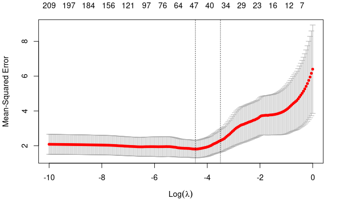

```r
m2 <- glmnet( x = x.ts.glmnet %>% as.matrix,
              y = y.ts_month %>% as.vector,
              alpha = 1, ## LASSO
              lambda = cv.m2$lambda.1se,
              family = "gaussian",
              standardize = TRUE)

coef(m2)
```

[output not shown]

```r
Arima(y.ts_month,
      c(0,0,1),
      xreg = dat.ts[,1] )
```

```
Series: y.ts_month
Regression with ARIMA(0,0,1) errors

Coefficients:
         ma1  intercept    xreg
      1.0000   -35.4882  0.3673
s.e.  0.0423     3.1918  0.0316

sigma^2 estimated as 2.867:  log likelihood=-158.27
AIC=324.54   AICc=325.06   BIC=334.12
```